# gRPC GSoC 2020

Shehab Hosny

## Overview

In this post I will try to wrap up my working progress throught GSoC 2020. I’ve been working since May trying to add new functionalities to the gRPC R package originally implemneted by Neal Faultz in 2017. There were a total of three tasks to implement, TLS Encryption, Oauth2 Authentication and finally Streaming. Here is the [link](https://github.com/Shehab7osny/grpc) for my forked repository.  
So, lets now strat discussing how I actually implemented TLS Encrytion to messages sent by both the client and the server.

[figure not shown]

## TLS Encryption

### client.cpp file updates:

The **createChannel()** function is used to create either a secure or insecure channel based on the boolean variable **useTLS** set by the user.

```cpp
grpc_channel* channel =
  createChannel(useTLS, server[0], certPath[0], tokenValue[0], isMetadataAttached);
```

Here is a detailed implementation for the **createChannel()** function.

```cpp
grpc_channel* createChannel(bool useTLS, const char* server ,const char* path,
                            const char* tokenValue, bool isMetadataAttached) {

  grpc_channel* channel;

  if(useTLS) {
    grpc_channel_credentials* client_creds =
      getClientCredentials(path, tokenValue, isMetadataAttached);
    channel =
      grpc_secure_channel_create(client_creds, server, NULL, nullptr);
  }

  else {
    channel =
      grpc_insecure_channel_create(server, NULL, nullptr);
  }

  return channel;
}
```

The **getClientCredentials()** function is used to generate the client credentials based on the TLS certificates provided by the user.

```cpp
grpc_channel_credentials* getClientCredentials(const char* path, const char* tokenValue,
                                               bool isMetadataAttached){

  files PEMfiles;

  PEMfiles.CAcert =
    get_file_contents(((std::string)path + "ca-cert.pem").c_str());
  PEMfiles.clientKey =
    get_file_contents(((std::string)path + "client-key.pem").c_str());
  PEMfiles.clientCert =
    get_file_contents(((std::string)path + "client-cert.pem").c_str());

  grpc_ssl_pem_key_cert_pair signed_client_key_cert_pair =
    {(PEMfiles.clientKey).c_str(), (PEMfiles.clientCert).c_str()};

  grpc_channel_credentials* creds = grpc_ssl_credentials_create(
    (PEMfiles.CAcert).c_str(), &signed_client_key_cert_pair, nullptr, nullptr);

  if(isMetadataAttached)
    return creds;

  grpc_call_credentials* oauth2Creds =
    grpc_access_token_credentials_create(getOauth2AccessToken(tokenValue), nullptr);

  grpc_channel_credentials* credsTLSOauth =
    grpc_composite_channel_credentials_create(creds, oauth2Creds, nullptr);

  return credsTLSOauth;
}
```

The **get_file_contents()** function is used to read the TLS certificates files.

```cpp
static std::string get_file_contents(const char *fpath) {
  std::ifstream finstream(fpath);

  std::string contents(
      (std::istreambuf_iterator<char>(finstream)),
      std::istreambuf_iterator<char>()
      );

  return contents;
}
```

### server.cpp file updates:

The **createPort()** function is used to create either a secure or insecure port based on the boolean variable **useTLS** set by the user.

```cpp
RGRPC_LOG("Bind");
int port =
  createPort(useTLS, server, hoststring[0], CertPath[0]);
params["port"] = port;
runFunctionIfProvided(hooks, "bind", params);
```

Here is a detailed implementation for the **createPort()** function.

```cpp
int createPort(bool useTLS, grpc_server* server, const char* hoststring, const char* CertPath) {

  int port;

  if(useTLS) {
    grpc_server_credentials* credentials = Get_TLS_Credentials(CertPath);
    port = grpc_server_add_secure_http2_port(server, hoststring, credentials);
    grpc_server_credentials_release(credentials);
  }

  else {
    port = grpc_server_add_insecure_http2_port(server, hoststring);
  }

  return port;
}
```

The **Get_TLS_Credentials()** function is used to generate the server credentials based on the TLS certificates provided by the user.

```cpp
grpc_server_credentials* Get_TLS_Credentials(const char* path) {

  std::string ca_cert_pem =
    get_file_contents(((std::string)path + "ca-cert.pem").c_str());
  std::string server_key_pem =
    get_file_contents(((std::string)path + "server-key.pem").c_str());
  std::string server_cert_pem =
    get_file_contents(((std::string)path + "server-cert.pem").c_str());

  grpc_ssl_pem_key_cert_pair pem_cert_key_pair =
    {server_key_pem.c_str(), server_cert_pem.c_str()};

  grpc_server_credentials* Creds =
    grpc_ssl_server_credentials_create_ex(
      ca_cert_pem.c_str(),
      &pem_cert_key_pair,
      1,
      GRPC_SSL_REQUEST_CLIENT_CERTIFICATE_AND_VERIFY,
      nullptr);

  return Creds;
}
```

### Script to generate TLS certificates:

```bash
rm *.pem

# 1. Generate CA's private key and self-signed certificate
openssl req -x509 -newkey rsa:4096 -days 365 -nodes -keyout ca-key.pem -out ca-cert.pem -subj
"/C=EG/ST=CairoEG/L=Cairo/O=GSoC/OU=CerAuth/CN=Cert/emailAddress=ca@gmail.com"

# 2. Generate web server's private key and certificate signing request (CSR)
openssl req -newkey rsa:4096 -nodes -keyout server-key.pem -out server-req.pem -subj
"/C=EG/ST=AlexEG/L=Alex/O=GSoC/OU=Server/CN=Server/emailAddress=server@gmail.com"

# 3. Use CA's private key to sign web server's CSR and get back the signed certificate
openssl x509 -req -in server-req.pem -days 60 -CA ca-cert.pem -CAkey ca-key.pem
-CAcreateserial -out server-cert.pem -extfile server-ext.cnf

# 4. Generate client's private key and certificate signing request (CSR)
openssl req -newkey rsa:4096 -nodes -keyout client-key.pem -out client-req.pem -subj
"/C=FR/ST=Alsace/L=Strasbourg/O=PC Client/OU=Computer/CN=Client/emailAddress=pcclient@gmail.com"

# 5. Use CA's private key to sign client's CSR and get back the signed certificate
openssl x509 -req -in client-req.pem -days 60 -CA ca-cert.pem -CAkey ca-key.pem
-CAcreateserial -out client-cert.pem
```

Here is a simple diagram to illustrate the TLS handshake process:

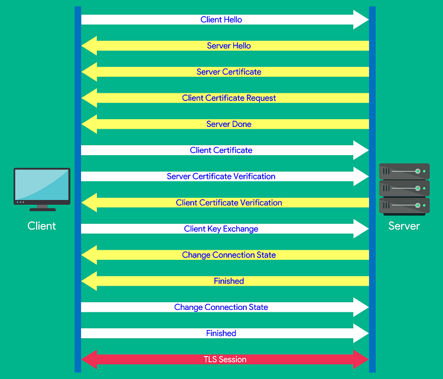

## Oauth2 Authentication

### client.cpp file updates:

The **getOauth2AccessToken()** function is used to return the access token set by the user.

```cpp
const char* getOauth2AccessToken(const char* tokenValue) {

  if(tokenValue == nullptr)
    stop("Access token value is not defined");

  const char* accessToken(tokenValue + sizeof("Bearer ") - 1);

  return accessToken;
}
```

### server.cpp file updates:

The **validateOauth2()** function is used to check the validate the Oauth2 token.

```cpp
bool validateOauth2(grpc_metadata_array metadataArray, Function checkAuthCallback) {

  Authentication_Token Oauth2;

  int Index = metadataArray.count - 2;

  if (metadataArray.count > 1) {

    Oauth2.Value =
      (std::string)grpc_slice_to_c_string(metadataArray.metadata[Index].value);

    Oauth2.Key =
      (std::string)grpc_slice_to_c_string(metadataArray.metadata[Index].key);

    bool Check = Rcpp::as<bool>(checkAuthCallback(Oauth2.Value));

    if(!Check)
      return false;
  }

  return true;
}
```

## Streaming

### client.R file updates:

```r
client_functions <- lapply(impl,
function(fn) {
  RequestDescriptor   <- P(fn[["RequestType"]]$proto)
  ResponseDescriptor  <- P(fn[["ResponseType"]]$proto)
    stream_bool <- fn[["ResponseType"]]$stream
    message <- list(
    call = function(x, metadata=character(0))
    {
      if(stream_bool) {
        i <- 1
        List_messages <- list()
        while(1) {
          message <- read(
            ResponseDescriptor,
            fetch(channel, fn$name, serialize(x, NULL), metadata, UseTLS, CertPath, AccessToken,
            ClientDeadline)
            )

          if(as.list(message) == '')
            break;

            List_messages[[i]] <- message
              i <- i + 1
            }
        }

      else {
        List_messages <- read(
        ResponseDescriptor,
        fetch(channel, fn$name, serialize(x, NULL), metadata, UseTLS, CertPath, AccessToken,
            ClientDeadline)
            )
        }

        List_messages
  },

  build = function(...) {
    new(RequestDescriptor, ...)
  }
  )
  message
}
)
```

### server.cpp file updates:

```cpp
// [[Rcpp::export]]
List streamMessage(RawVector response) {

  grpc_op ops[6];
  grpc_op *op;
  int was_cancelled = 2;

  if(messageCount > 1) {
      //Client Mutex starts here
      do {
          memset(ops, 0, sizeof(ops));

          grpc_server_request_call(*Server_Global, Call_Global,
                           Details_Global, Metadata_Global, *Queue_Global, *Queue_Global, NULL);

          gpr_timespec c_increment =
              gpr_time_from_millis(_INTERRUPT_CHECK_PERIOD_MS, GPR_TIMESPAN);

          gpr_timespec c_timeout =
              gpr_time_add(gpr_now(GPR_CLOCK_REALTIME), c_increment);

          *Event_Global = grpc_completion_queue_next(*Queue_Global, c_timeout, RESERVED);

      } while((*Event_Global).type != GRPC_OP_COMPLETE);
      //Client Mutex ends here

      memset(ops, 0, sizeof(ops));
      op = ops;

      RGRPC_LOG("GRPC_OP_SEND_INITIAL_METADATA");
      op -> op = GRPC_OP_SEND_INITIAL_METADATA;
      op -> data.send_initial_metadata.count = 0;
      op -> data.send_initial_metadata.maybe_compression_level.is_set = false;
      op -> flags = 0;
      op -> reserved = NULL;
      op++;

      RGRPC_LOG("GRPC_OP_RECV_MESSAGE");
      op -> op = GRPC_OP_RECV_MESSAGE;
      op -> data.recv_message.recv_message = Request_Global;
      op -> flags = 0;
      op -> reserved = NULL;
      op++;

      grpc_call_start_batch(*Call_Global, ops, (size_t)(op - ops), NULL, NULL);
      grpc_completion_queue_next(*Queue_Global, *Timespec_Global, RESERVED);
  }

  messageCount = messageCount + 1;

  char const * status_details_string = "OK";

  int len = response.length();
  SEXP raw_ = response;
  grpc_slice response_payload_slice = grpc_slice_from_copied_buffer((char*) RAW(raw_), len);
  grpc_byte_buffer* response_payload = grpc_raw_byte_buffer_create(&response_payload_slice, 1);
  grpc_slice_unref(response_payload_slice);

  memset(ops, 0, sizeof(ops));
  op = ops;

  RGRPC_LOG("GRPC_OP_RECV_CLOSE_ON_SERVER");
  op -> op = GRPC_OP_RECV_CLOSE_ON_SERVER;
  op -> data.recv_close_on_server.cancelled = &was_cancelled;
  op -> flags = 0;
  op -> reserved = NULL;
  op++;

  RGRPC_LOG("GRPC_OP_SEND_MESSAGE");
  op -> op = GRPC_OP_SEND_MESSAGE;
  op -> data.send_message.send_message = response_payload;
  op -> flags = 0;
  op -> reserved = NULL;
  op++;

  RGRPC_LOG("GRPC_OP_SEND_STATUS_FROM_SERVER 1");
  op -> op = GRPC_OP_SEND_STATUS_FROM_SERVER;
  op -> data.send_status_from_server.trailing_metadata_count = 0;

  op -> data.send_status_from_server.status = *Status_Code_Global;
  grpc_slice status_details = grpc_slice_from_static_string(status_details_string);

  op -> data.send_status_from_server.status_details = &status_details;
  op -> flags = 0;
  op -> reserved = NULL;
  op++;

  RGRPC_LOG("Starts the process of Streaming!");
  grpc_call_start_batch(*Call_Global, ops, (size_t)(op - ops), NULL, NULL);
  *Event_Global = grpc_completion_queue_next(*Queue_Global, *Timespec_Global, RESERVED);

  grpc_byte_buffer_destroy(response_payload);

  return List::create();
}
```

## Example #1 (Unary Streaming invloving TLS and Oauth2)

### Server-side:

```r
#' Example gRPC service
#'
#' Reads a message with a name and returns a message greeting the name.
#' @references \url{https://github.com/grpc/grpc/tree/master/examples/cpp/helloworld}

library(grpc)

## reading the service definitions
spec <- system.file('examples/helloworld.proto', package = 'grpc')

impl <- read_services(spec)

options(UseTLS = TRUE)
options(CertPath = "/home/shehab/Dropbox/gRPC/Certificates/")
options(AccessToken = "Bearer Token Shehab and Neal")

impl$SayHello$f <- function(request){
  newResponse(message = paste('Hello,', request$name))
}

impl$SayThanks$f <- function(request){
  newResponse(message = paste('Thanks,', request$name))
}

impl$SayBye$f <- function(request){
  newResponse(message = paste('Bye,', request$name))
}

## actually running the service handlers
start_server(impl, "0.0.0.0:50051")
```

### Client-side:

```r
#' Example gRPC client
#'
#' Sends a message with a name and returns a message greeting the name.
#' @references \url{https://github.com/grpc/grpc/tree/master/examples/cpp/helloworld}

library(grpc)


spec <- system.file('examples/helloworld.proto', package = 'grpc')
impl <- read_services(spec)

options(UseTLS = TRUE)
options(CertPath = "/home/shehab/Dropbox/gRPC/Certificates/")
options(AccessToken = "Bearer Token Shehab and Neal")
options(ClientDeadline = 10)

client <- grpc_client(impl, "localhost:50051")

for(who in c("Neal")){

    hello <- client$SayHello$build(name=who)
    message <- client$SayHello$call(hello)

    print(as.list(message))

    thanks <- client$SayThanks$build(name=who)
    message <- client$SayThanks$call(thanks, c("authorization", "Bearer Token Shehab and Neal"))

    print(as.list(message))

    bye <- client$SayBye$build(name=who)
    message <- client$SayBye$call(bye)

    print(as.list(message))
}
```

### Output (Valid Encryption and Authentication):

```r
$message
[1] "Hello, Neal"

$message
[1] "Thanks, Neal"

$message
[1] "Bye, Neal"
```

### Output (Invalid Encryption):

```r
Invalid private key.
Handshaker factory creation failed with TSI_INVALID_ARGUMENT.
Failed to create secure subchannel for secure name 'localhost:50051'
Failed to create channel args during subchannel creation.
Error in fetch(channel, fn$name, serialize(x, NULL), metadata, UseTLS,  :
  No response from the gRPC server
Calls: demo ... eval -> eval -> <Anonymous> -> read -> fetch -> .Call
Execution halted
```

### Output (Invalid Authentication):

```r
Error in fetch(channel, fn$name, serialize(x, NULL), metadata, UseTLS,  :
  The request does not have valid authentication credentials
Calls: demo ... eval -> eval -> <Anonymous> -> read -> fetch -> .Call
Execution halted
```

## Example #2 (Streaming invloving TLS and Oauth2)

### Server-side:

```r
#' Example gRPC service
#'
#' Reads a message with a name and returns a stream of messages involving the name.
#' @references \url{https://github.com/grpc/grpc/tree/master/examples/cpp/helloworld}

library(grpc)

## reading the service definitions
spec <- system.file('examples/helloworld.proto', package = 'grpc')

impl <- read_services(spec)

options(UseTLS = TRUE)
options(CertPath = "/home/shehab/Dropbox/gRPC/Certificates/")
options(AccessToken = "Bearer Token Shehab and Neal")

impl$SayEverything$f <- function(request){
  newResponse(message = paste('Your name is ', request$name))
  newResponse(message = paste('Hello,', request$name))
  newResponse(message = paste('I hope you are enjoying your day,', request$name))
  newResponse(message = paste('Thanks,', request$name))
  newResponse(message = paste('Have a great day,', request$name))
  newResponse(message = paste('Bye,', request$name))
}

## actually running the service handlers
start_server(impl, "0.0.0.0:50051")
```

### Client-side:

```r
#' Example gRPC client
#'
#' Sends a message with a name and returns a stream of messages involving the name.
#' @references \url{https://github.com/grpc/grpc/tree/master/examples/cpp/helloworld}

library(grpc)

spec <- system.file('examples/helloworld.proto', package = 'grpc')
impl <- read_services(spec)

options(UseTLS = TRUE)
options(CertPath = "/home/shehab/Dropbox/gRPC/Certificates/")
options(AccessToken = "Bearer Token Shehab and Neal")
options(ClientDeadline = 10)

client <- grpc_client(impl, "localhost:50051")

everything <- client$SayEverything$build(name='Shehab')
queue <- client$SayEverything$call(everything,
         c("authorization", "Bearer Token Shehab and Neal"))

for (message in queue) {
    print(as.list(message))
}
```

### Output (Valid Encryption and Authentication):

```r
$message
[1] "Your name is  Shehab"

$message
[1] "Hello, Shehab"

$message
[1] "I hope you are enjoying your day, Shehab"

$message
[1] "Thanks, Shehab"

$message
[1] "Have a great day, Shehab"

$message
[1] "Bye, Shehab"
```